# A Vibe Coding Session I’m Proud Of

## What I Built

For this submission, I’m sharing an election-survey analysis pipeline I built with ChatGPT as a coding copilot. I chose this project because it shows how I use AI for more than quick code generation: I use it to accelerate development, then audit the output, catch what is wrong or incomplete, and improve the system so it actually works end to end.

The prompt asks for something built with AI that shows I can “drive,” and this project is a good example of that because it combines data ingestion, cleaning, storage, modeling, and iteration into one workflow.

## Project Goal

The goal of the project was to simulate a realistic political survey workflow. Instead of treating a survey as a single CSV that gets analyzed once, I built a pipeline that can take in repeated survey waves over time, clean them, load them into SQLite, connect them to respondent and voter-history information, build a modeling table, run predictive models, and save outputs for downstream analysis.

The point was to turn raw survey responses into something a campaign, political consulting team, or research group could actually use to track support, turnout likelihood, and issue patterns over time.

At a high level, the project does four things:

1. Organizes the data into a relational structure instead of leaving everything in one messy file.
2. Processes new survey waves as they arrive.
3. Creates an analysis-ready `modeling_dataset` by joining multiple tables together.
4. Runs multiple models to generate predictions and summary outputs that can be saved back into SQLite.

The result is not just a model and not just a database—it is a full analysis pipeline.

## Main Tables Used

### `respondents`

One row per person, storing mostly stable demographic information such as `respondent_id`, age, age group, gender, race/ethnicity, education, income bracket, county, state, urbanicity, party registration, and ideology. This table gives the project the person-level background variables used later for weighting, subgroup analysis, and modeling.

### `voter_history`

One row per respondent, storing turnout and participation history such as whether the person is registered to vote, whether they voted in recent general and primary elections, counts of how many elections they participated in, and a turnout-frequency score. This table matters because prior voting behavior is often one of the strongest predictors in political analysis.

### `survey_metadata`

One row per survey wave, storing wave-level information such as `survey_id`, survey name, field dates, survey mode, sample size, target population, geography, election ID, and weighting notes. This table lets the pipeline distinguish one wave from another and connect wave-specific responses back to the broader election context.

### `survey_responses`

The heart of the system, with one row per respondent per survey wave. This table stores the actual answers: `response_id`, `respondent_id`, `survey_id`, completion status, weight, registration status, likelihood to vote, vote intent, second choice, support strength, candidate favorability, candidate familiarity, top issue, party ID, ideology, right-direction questions, incumbent approval, and an optional open comment. This is the table that grows as new waves come in.

### `elections`

One row per election or race, storing the election context such as office, election date, district, and election type. This table helps anchor the project in a specific race rather than treating the survey data as abstract responses without context.

### `candidates`

One row per candidate, storing fields like `candidate_id`, `election_id`, candidate name, party, and incumbent status. This gives the election structure a candidate-level component and makes the schema more realistic.

### `modeling_dataset`

From those base tables, I built a final `modeling_dataset` table that joins survey responses with respondent demographics, voter history, and survey metadata, and also creates model-friendly binary targets such as support for Maria Elvira Salazar, support for Eliott Rodriguez, undecided status, and likely-voter status. That merged table is the dataset the machine-learning models actually use.

## Pipeline Workflow

The workflow of the pipeline is:

1. A new survey wave arrives as a CSV.
2. The file is checked for the expected columns.
3. The data is cleaned, filtered to complete responses, and deduplicated by `response_id`.
4. The wave is compared against the existing SQLite `survey_responses` table so only truly new rows are loaded.
5. The pipeline rebuilds `modeling_dataset`.
6. Multiple models are trained or rerun.
7. Prediction outputs for each model are saved back into SQLite.
8. Comparison and summary tables are updated.

That structure makes the project look less like a one-off notebook and more like a reusable analytics workflow.

## How I Used AI

ChatGPT helped me scaffold the folder structure, the SQLite load logic, the SQL for the modeling table, and the initial preprocessing and modeling pipelines. That gave me a fast starting point.

I used AI to speed up repetitive and structural work, including:

- pipeline scaffolding
- SQL generation
- preprocessing setup
- model pipeline setup
- explanation and iteration on code

## What AI Missed and What I Fixed

What I’m most proud of is not just that the pipeline works, but that I actively improved the AI-generated code instead of accepting it blindly.

As I reviewed the code closely, I found several important gaps and mistakes that needed to be fixed.

### Missing append step for new rows

The original pipeline checked for new survey rows against existing `response_id` values in SQLite, but the append step to actually load those new rows into `survey_responses` was missing from the version I was working through. I caught that and added the logic so the pipeline would truly ingest new wave data instead of only identifying it.

### Missing Random Forest prediction export

The pipeline saved prediction tables for logistic regression and the neural network, but it forgot to save the random forest prediction outputs. I added a matching export step so all three models now save their probabilities and class predictions consistently into SQLite.

### Hard-coded model comparison values

The model comparison table originally used hard-coded accuracy values. That meant the comparison would become stale if I changed the models, improved preprocessing, or processed new survey waves. I replaced that with logic that builds the comparison table from the actual current model evaluation results, so it updates dynamically instead of relying on manually typed numbers.

### Missing automation for `survey_metadata`

New survey-response files could be ingested automatically from the incoming folder, but `survey_metadata` was not being refreshed from the CSV tables folder before rebuilding the modeling dataset. Since the modeling SQL joins on `survey_id`, that meant new waves could load into `survey_responses` but still have missing metadata context in the joined table. I added a code block to reload `survey_metadata` into SQLite automatically before rebuilding `modeling_dataset`, which made the pipeline much smoother and more realistic.

### Inconsistent preprocessing across models

The neural-network pipeline included numeric standardization, but the logistic regression pipeline did not, even though some continuous numeric inputs like age and turnout-related counts should also have been considered for scaling. I documented that issue clearly and flagged it as a missed step in the original AI-generated version.

## Why I’m Proud Of This

This project is a good example of how I like to work with AI tools. I use them to move faster on scaffolding, repetitive code, SQL, pipeline structure, and first drafts of model pipelines, but I do not treat the output as automatically correct.

I inspect the logic, compare code behavior against the intended workflow, test edge cases, and make targeted fixes. In this case, AI sped up the build, but the final quality came from reviewing, debugging, and improving what it produced.

## What to Pay Attention To

The main thing I would want a reviewer to notice is my judgment in the loop: not just that I used AI, but that I used it actively.

The interesting part of this project is not “ChatGPT wrote some code.” It’s that I used AI to accelerate an end-to-end survey pipeline, then identified where the generated pipeline was incomplete, brittle, or overly manual, and improved it into something more consistent and automated.

## Importing Libraries

```python
import sys
!"{sys.executable}" -m pip install pandas scikit-learn
```

```python
%pip install pandas scikit-learn
```

```python
from pathlib import Path
import os #os helps the code interact with the operating system like: check if a file exists, work with folder names, create directories, inspect file paths, interact with environment-level file behavior
import shutil #This imports shutil, which is used for moving, copying, or deleting files and folders.
import sqlite3
import pandas as pd
from datetime import datetime
```

## Connecting to the folder where the database is

```python
# Base project folder
BASE_DIR = Path(r"C:\Users\Oscars Account\Downloads\Survey data project for Echelon\Files")

# Key folders
INCOMING_DIR = BASE_DIR / "incoming" #This creates the path for the incoming folder. This is the folder where new survey waves CSV files arrive first.
ARCHIVE_DIR = BASE_DIR / "archive"   #This is where processed files are moved after the pipeline finishes with them. archive = old files that were already processed
EXPORTS_DIR = BASE_DIR / "exports" #This folder is for things the pipeline produces. Exports = files created by the project
LOGS_DIR = BASE_DIR / "logs" #logs tracks the pipeline’s activity. logs = notes about what happened during the pipeline run

# Database path
DB_PATH = BASE_DIR / "survey_project.db" #the address of the database file.DB_PATH = where the SQLite database lives

# Create folders if they do not exist
for folder in [INCOMING_DIR, ARCHIVE_DIR, EXPORTS_DIR, LOGS_DIR]:
    folder.mkdir(exist_ok=True)   #mkdir means make directory, which just means create folder. exist_ok=True: If the folder already exists, do not crash and do not complain. Without exist_ok=True, Python could throw an error if the folder was already there.

print("Base folder:", BASE_DIR)
print("Database exists:", DB_PATH.exists()) #DB_PATH.exists() returns either: True or False. It checks whether the database file is already in the project folder
print("Incoming folder:", INCOMING_DIR) #It helps make sure the script knows where to look for new survey files.
```

```
Base folder: C:\Users\Oscars Account\Downloads\Survey data project for Echelon\Files
Database exists: True
Incoming folder: C:\Users\Oscars Account\Downloads\Survey data project for Echelon\Files\incoming
```

```python
conn = sqlite3.connect(DB_PATH) #opens a connection to the SQLite database.

tables = pd.read_sql(
    """
    SELECT name
    FROM sqlite_master
    WHERE type='table'
    ORDER BY name
    """,
    conn
)  #sqlite_master is a special built-in table in SQLite. It's SQLite’s internal directory. It keeps track of: tables, indexes, views, and other database objects. In this case it only shows tables

print(tables)

for table in tables["name"]: #This starts a loop. It goes through the name column from the tables result, one table at a time. For each table in the database, do the next step
    count = pd.read_sql(f"SELECT COUNT(*) AS n FROM {table}", conn) #This line asks the database: “How many rows are in this table?” FROM {table} This means the query changes depending on the current table name in the loop.
    print(table, count["n"][0]) #This prints the table name and the number of rows in that table

conn.close()
```

```
                       name
0                candidates
1                 elections
2   logreg_vote_predictions
3          model_comparison
4             model_outputs
5          modeling_dataset
6       nn_vote_predictions
7               respondents
8       rf_vote_predictions
9           survey_metadata
10         survey_responses
11            voter_history
candidates 2
elections 1
logreg_vote_predictions 3424
model_comparison 3
model_outputs 3000
modeling_dataset 3679
nn_vote_predictions 3424
respondents 3000
rf_vote_predictions 3424
survey_metadata 5
survey_responses 3679
voter_history 3000
```

```python
csv_files = list(INCOMING_DIR.glob("*.csv")) #It finds every file in the incoming folder using .glob whose name ends with .csv. list(...) This turns the found files into a list so Python can work with them more easily.

if not csv_files:   #This checks whether the list is empty.
    print("No CSV files found in incoming folder.")
else:
    latest_file = max(csv_files, key=os.path.getmtime) #look at all the CSV files in the list, check the time each one was last modified, choose the one with the most recent time. os.path.getmtime: This gets the file’s modification time
    print("Latest file found:", latest_file.name) #This gives only the file’s name, not the full long path.
```

```
Latest file found: fl27_wave_005.csv
```

```python
#This code opens the new survey file and gives a quick preview to see what is inside before processing it.
raw_df = pd.read_csv(latest_file)

print("Shape:", raw_df.shape)
print("\nColumns:")
print(raw_df.columns.tolist())

raw_df.head()
```

```
Shape: (750, 35)

Columns:
['response_id', 'respondent_id', 'survey_id', 'response_date', 'completion_status', 'weight', 'q_registered_vote', 'q_likelihood_vote', 'q_vote_intent', 'q_vote_intent_lean', 'q_second_choice', 'q_support_strength', 'q_favorability_salazar', 'q_favorability_eliott_rodriguez', 'q_familiarity_salazar'…
```

|  | response_id | respondent_id | survey_id | response_date | completion_status | weight | q_registered_vote | q_likelihood_vote | q_vote_intent | q_vote_intent_lean | ... | q_trust_crime | q_trust_cost_of_living | q_party_id | q_party_strength | q_ideology_self | q_past_vote_2024 | q_right_direction_country | q_right_direction_local | q_job_approval_incumbent_rep | q_open_comment |
| --- | --- | --- | --- | --- | --- | --- | --- | --- | --- | --- | --- | --- | --- | --- | --- | --- | --- | --- | --- | --- | --- |
| 0 | RESP_03381 | R01742 | FL27_WAVE_005 | 2026-05-27 00:38:12 | Complete | 1.407 | Yes | Definitely will vote | Maria Elvira Salazar | Not asked | ... | Eliott Rodriguez | Not sure | Republican | Lean | Moderate | Kamala Harris | Wrong track | Wrong track | Strongly approve | Need stronger leadership on cost of living |
| 1 | RESP_03465 | R02377 | FL27_WAVE_005 | 2026-05-27 00:46:52 | Complete | 0.668 | Yes | Definitely will vote | Eliott Rodriguez | Not asked | ... | Eliott Rodriguez | Eliott Rodriguez | Independent | Lean | Liberal | Donald Trump | Wrong track | Not sure | Strongly disapprove | NaN |
| 2 | RESP_03575 | R01819 | FL27_WAVE_005 | 2026-05-27 00:50:56 | Complete | 1.057 | Yes | Definitely will vote | Eliott Rodriguez | Not asked | ... | Eliott Rodriguez | Eliott Rodriguez | Democrat | Not asked | Very liberal | Donald Trump | Right direction | Wrong track | Somewhat disapprove | NaN |
| 3 | RESP_03104 | R00039 | FL27_WAVE_005 | 2026-05-27 00:53:00 | Complete | 0.912 | Yes | Definitely will vote | Eliott Rodriguez | Not asked | ... | Eliott Rodriguez | Neither | Republican | Lean | Very liberal | Kamala Harris | Wrong track | Wrong track | Somewhat disapprove | NaN |
| 4 | RESP_03707 | R02624 | FL27_WAVE_005 | 2026-05-27 00:56:32 | Complete | 0.907 | No | Probably will not vote | Maria Elvira Salazar | Not asked | ... | Maria Elvira Salazar | Maria Elvira Salazar | Independent | Lean | Very conservative | Kamala Harris | Right direction | Wrong track | Somewhat approve | Healthcare costs are too high |

5 rows × 35 columns

## Structuring the table I will work with

```python
survey_response_columns = [
    "response_id",
    "respondent_id",
    "survey_id",
    "response_date",
    "completion_status",
    "weight",
    "q_registered_vote",
    "q_likelihood_vote",
    "q_vote_intent",
    "q_vote_intent_lean",
    "q_second_choice",
    "q_support_strength",
    "q_favorability_salazar",
    "q_favorability_eliott_rodriguez",
    "q_familiarity_salazar",
    "q_familiarity_eliott_rodriguez",
    "q_most_important_issue",
    "q_trust_economy",
    "q_trust_immigration",
    "q_trust_crime",
    "q_trust_cost_of_living",
    "q_party_id",
    "q_party_strength",
    "q_ideology_self",
    "q_past_vote_2024",
    "q_right_direction_country",
    "q_right_direction_local",
    "q_job_approval_incumbent_rep",
    "q_open_comment"
]

missing_cols = [col for col in survey_response_columns if col not in raw_df.columns] #This line creates a list called missing_cols. It checks every expected column in survey_response_columns and asks: “Is this column missing from the actual raw_df.CSV file?” If the answer is yes, it adds that column name to the list.
extra_cols = [col for col in raw_df.columns if col not in survey_response_columns] #It looks at the actual columns in the CSV file and asks: “Is this column not part of my expected official list?” If a column is in the file but not in your expected list, it gets added to extra_cols.

print("Missing columns:", missing_cols)
print("Extra columns:", extra_cols)

#Note: Chatgpt decided to leave the extra columns excluded from the survey_response structure. This is a little confusing because the earlier project design actually described
#survey_responses as including columns like q_issue_economy, q_issue_immigration, q_issue_crime, q_issue_education, q_issue_healthcare, and q_issue_housing but the current pipeline code
#leaves them out of survey_response_columns. This is something that needs to be fixed in the pipeline.
```

```
Missing columns: []
Extra columns: ['q_issue_economy', 'q_issue_immigration', 'q_issue_crime', 'q_issue_education', 'q_issue_healthcare', 'q_issue_housing']
```

```python
load_df = raw_df[survey_response_columns].copy()

# basic cleaning
load_df.columns = load_df.columns.str.strip() #removes extra spaces at the beginning and end of text. For example: " response_id" becomes "response_id", "weight " becomes "weight"

for col in load_df.select_dtypes(include="object").columns: #go through each column that contains text
    load_df[col] = load_df[col].astype(str).str.strip() #This line cleans the text inside each text column. It does two things: astype(str), this forces the values to be treated as strings/text. str.strip(): This removes extra spaces at the beginning and end of each value.

load_df["response_date"] = pd.to_datetime(load_df["response_date"], errors="coerce") #This converts the response_date column into a real date format. errors="coerce", if a value cannot be turned into a valid date, do not crash — instead turn it into a missing value
load_df["weight"] = pd.to_numeric(load_df["weight"], errors="coerce") #This converts the weight column into a real number.

load_df = load_df[load_df["completion_status"] == "Complete"].copy() # keep only complete responses

load_df = load_df.drop_duplicates(subset=["response_id"]) #remove duplicate response IDs inside the file

print("Cleaned load_df shape:", load_df.shape)
load_df.head()
```

```
Cleaned load_df shape: (679, 29)
```

[output not shown]

|  | response_id | respondent_id | survey_id | response_date | completion_status | weight | q_registered_vote | q_likelihood_vote | q_vote_intent | q_vote_intent_lean | ... | q_trust_crime | q_trust_cost_of_living | q_party_id | q_party_strength | q_ideology_self | q_past_vote_2024 | q_right_direction_country | q_right_direction_local | q_job_approval_incumbent_rep | q_open_comment |
| --- | --- | --- | --- | --- | --- | --- | --- | --- | --- | --- | --- | --- | --- | --- | --- | --- | --- | --- | --- | --- | --- |
| 0 | RESP_03381 | R01742 | FL27_WAVE_005 | 2026-05-27 00:38:12 | Complete | 1.407 | Yes | Definitely will vote | Maria Elvira Salazar | Not asked | ... | Eliott Rodriguez | Not sure | Republican | Lean | Moderate | Kamala Harris | Wrong track | Wrong track | Strongly approve | Need stronger leadership on cost of living |
| 1 | RESP_03465 | R02377 | FL27_WAVE_005 | 2026-05-27 00:46:52 | Complete | 0.668 | Yes | Definitely will vote | Eliott Rodriguez | Not asked | ... | Eliott Rodriguez | Eliott Rodriguez | Independent | Lean | Liberal | Donald Trump | Wrong track | Not sure | Strongly disapprove | NaN |
| 2 | RESP_03575 | R01819 | FL27_WAVE_005 | 2026-05-27 00:50:56 | Complete | 1.057 | Yes | Definitely will vote | Eliott Rodriguez | Not asked | ... | Eliott Rodriguez | Eliott Rodriguez | Democrat | Not asked | Very liberal | Donald Trump | Right direction | Wrong track | Somewhat disapprove | NaN |
| 3 | RESP_03104 | R00039 | FL27_WAVE_005 | 2026-05-27 00:53:00 | Complete | 0.912 | Yes | Definitely will vote | Eliott Rodriguez | Not asked | ... | Eliott Rodriguez | Neither | Republican | Lean | Very liberal | Kamala Harris | Wrong track | Wrong track | Somewhat disapprove | NaN |
| 4 | RESP_03707 | R02624 | FL27_WAVE_005 | 2026-05-27 00:56:32 | Complete | 0.907 | No | Probably will not vote | Maria Elvira Salazar | Not asked | ... | Maria Elvira Salazar | Maria Elvira Salazar | Independent | Lean | Very conservative | Kamala Harris | Right direction | Wrong track | Somewhat approve | Healthcare costs are too high |

5 rows × 29 columns

```python
conn = sqlite3.connect(DB_PATH)

existing_ids = pd.read_sql("SELECT response_id FROM survey_responses", conn) #go to the survey_responses table and give me every response ID already saved there. The results are stored in existing_ids. So existing_ids becomes a list/table of all the response IDs already inside SQLite.

new_rows_df = load_df[~load_df["response_id"].isin(existing_ids["response_id"])].copy() #It compares the response IDs in the cleaned CSV (load_df) against the response IDs already in the database (existing_ids). This returns True or False for each row. The ~ means NOT. keep the rows whose response IDs are NOT already in the database

print("Rows in CSV:", len(load_df))
print("New rows not already in SQLite:", len(new_rows_df))
```

```
Rows in CSV: 679
New rows not already in SQLite: 0
```

```python
#Chatgpt did not include this part of the code when the pipeline was created. This is an important step because the logic is: clean the incoming file, compare it to existing
#survey_responses rows, keep only truly new rows, if any new rows remai, append them into survey_responses, if none remain, print a message and do nothing.

if len(new_rows_df) > 0:
    new_rows_df.to_sql("survey_responses", conn, if_exists="append", index=False)
    print(f"Loaded {len(new_rows_df)} new rows into survey_responses.")
else:
    print("No new rows to load.")

conn.close()
```

```
No new rows to load.
```

```python
## NOTE:
# This code block reloads the survey_metadata CSV file from the CSV tables folder into
# the SQLite database before rebuilding modeling_dataset. Its purpose is to make sure
# the pipeline is using the most up-to-date survey wave metadata, such as new survey_id
# entries like FL27_WAVE_005, when the modeling table is recreated. This is an important
# automation step because the original ChatGPT-generated pipeline did not include it,
# which meant survey_metadata had to be updated manually in SQLite outside the main flow.

survey_metadata_path = r"C:\Users\Oscars Account\Downloads\Survey data project for Echelon\CSV tables\survey_metadata.csv"

metadata_df = pd.read_csv(survey_metadata_path)

conn = sqlite3.connect(DB_PATH)
metadata_df.to_sql("survey_metadata", conn, if_exists="replace", index=False)
print("survey_metadata reloaded from CSV into SQLite.")
conn.close()
```

```
survey_metadata reloaded from CSV into SQLite.
```

```python
#Building a new table called modeling_dataset inside SQLite. It takes information that was split across several tables and puts it together into one place so it is easier to model and analyze.

conn = sqlite3.connect(DB_PATH)

modeling_sql = """
DROP TABLE IF EXISTS modeling_dataset;

CREATE TABLE modeling_dataset AS
SELECT
    sr.response_id,
    sr.respondent_id,
    sr.survey_id,
    sm.election_id,
    sr.response_date,
    sr.weight,

    sr.q_vote_intent,
    sr.q_likelihood_vote,
    sr.q_vote_intent_lean,
    sr.q_support_strength,
    sr.q_favorability_salazar,
    sr.q_favorability_eliott_rodriguez,
    sr.q_familiarity_salazar,
    sr.q_familiarity_eliott_rodriguez,
    sr.q_most_important_issue,
    sr.q_trust_economy,
    sr.q_trust_immigration,
    sr.q_trust_crime,
    sr.q_trust_cost_of_living,
    sr.q_party_id,
    sr.q_party_strength,
    sr.q_ideology_self,
    sr.q_past_vote_2024,
    sr.q_right_direction_country,
    sr.q_right_direction_local,
    sr.q_job_approval_incumbent_rep,

    r.age,
    r.age_group,
    r.gender,
    r.race_ethnicity,
    r.education,
    r.income_bracket,
    r.county,
    r.state,
    r.urbanicity,
    r.party_registration,
    r.ideology,

    vh.registered_to_vote,
    vh.voted_2020_general,
    vh.voted_2022_general,
    vh.voted_2024_general,
    vh.voted_2022_primary,
    vh.voted_2024_primary,
    vh.general_elections_voted_count,
    vh.primary_elections_voted_count,
    vh.turnout_frequency_score,

    CASE
        WHEN sr.q_vote_intent = 'Maria Elvira Salazar' THEN 1
        ELSE 0
    END AS support_salazar_binary,

    CASE
        WHEN sr.q_vote_intent = 'Eliott Rodriguez' THEN 1
        ELSE 0
    END AS support_rodriguez_binary,

    CASE
        WHEN sr.q_vote_intent = 'Undecided' THEN 1
        ELSE 0
    END AS undecided_binary,

    CASE
        WHEN sr.q_likelihood_vote IN ('Definitely will vote', 'Probably will vote') THEN 1
        ELSE 0
    END AS likely_voter_binary

FROM survey_responses sr
LEFT JOIN respondents r
    ON sr.respondent_id = r.respondent_id
LEFT JOIN voter_history vh
    ON sr.respondent_id = vh.respondent_id
LEFT JOIN survey_metadata sm
    ON sr.survey_id = sm.survey_id;
"""

conn.executescript(modeling_sql) #run all the SQL instructions to rebuild the modeling table
print("Created modeling_dataset.")
```

```
Created modeling_dataset.
```

```python
#Checking that the new table is correct

modeling_df = pd.read_sql("SELECT * FROM modeling_dataset LIMIT 5", conn)
print(modeling_df.head())
```

```
  response_id respondent_id      survey_id    election_id  \
0  RESP_00001        R00001  FL27_WAVE_001  FL27_GEN_2026
1  RESP_00002        R00002  FL27_WAVE_001  FL27_GEN_2026
2  RESP_00003        R00003  FL27_WAVE_001  FL27_GEN_2026
3  RESP_00004        R00004  FL27_WAVE_001  FL27_GEN_2026
4  RESP_00005        R00005  FL27_WAVE_001  FL27_GEN_2026

         response_date  weight         q_vote_intent  \
0  2026-04-03 14:32:00   1.040  Maria Elvira Salazar
1  2026-04-03 14:32:00   0.715      Eliott Rodriguez
2  2026-04-03 14:32:00   1.123  Maria Elvira Salazar
3  2026-04-03 14:32:00   0.885             Undecided
4  2026-04-03 14:32:00   0.788  Maria Elvira Salazar

          q_likelihood_vote    q_vote_intent_lean q_support_strength  ...  \
```

[output cut: 35 more lines]

```python
#Counting and checking the number of rows of the modeling_dataset table

pd.read_sql("SELECT COUNT(*) AS n FROM modeling_dataset", conn)
```

|  | n |
| --- | --- |
| 0 | 3679 |

```python
#Selecting all the columns and rows of modeling_dataset and calling it modeling_df
modeling_df = pd.read_sql("SELECT * FROM modeling_dataset", conn)

print(modeling_df.shape)
modeling_df.head()
```

```
(3679, 50)
```

|  | response_id | respondent_id | survey_id | election_id | response_date | weight | q_vote_intent | q_likelihood_vote | q_vote_intent_lean | q_support_strength | ... | voted_2024_general | voted_2022_primary | voted_2024_primary | general_elections_voted_count | primary_elections_voted_count | turnout_frequency_score | support_salazar_binary | support_rodriguez_binary | undecided_binary | likely_voter_binary |
| --- | --- | --- | --- | --- | --- | --- | --- | --- | --- | --- | --- | --- | --- | --- | --- | --- | --- | --- | --- | --- | --- |
| 0 | RESP_00001 | R00001 | FL27_WAVE_001 | FL27_GEN_2026 | 2026-04-03 14:32:00 | 1.040 | Maria Elvira Salazar | Definitely will not vote | Maria Elvira Salazar | Very strong | ... | 1 | 0 | 0 | 2 | 0 | 0.457 | 1 | 0 | 0 | 0 |
| 1 | RESP_00002 | R00002 | FL27_WAVE_001 | FL27_GEN_2026 | 2026-04-03 14:32:00 | 0.715 | Eliott Rodriguez | Probably will not vote | Eliott Rodriguez | Very strong | ... | 0 | 0 | 0 | 0 | 0 | 0.302 | 0 | 1 | 0 | 0 |
| 2 | RESP_00003 | R00003 | FL27_WAVE_001 | FL27_GEN_2026 | 2026-04-03 14:32:00 | 1.123 | Maria Elvira Salazar | Probably will vote | Maria Elvira Salazar | Somewhat strong | ... | 0 | 0 | 0 | 1 | 0 | 0.476 | 1 | 0 | 0 | 1 |
| 3 | RESP_00004 | R00004 | FL27_WAVE_001 | FL27_GEN_2026 | 2026-04-03 14:32:00 | 0.885 | Undecided | Probably will not vote | Maria Elvira Salazar | Not asked | ... | 0 | 0 | 0 | 0 | 0 | 0.286 | 0 | 0 | 1 | 0 |
| 4 | RESP_00005 | R00005 | FL27_WAVE_001 | FL27_GEN_2026 | 2026-04-03 14:32:00 | 0.788 | Maria Elvira Salazar | Probably will vote | Maria Elvira Salazar | Somewhat strong | ... | 0 | 1 | 0 | 3 | 1 | 0.604 | 1 | 0 | 0 | 1 |

5 rows × 50 columns

```python
#Checking support for Salazar and Rodriguez. In addition, checking the amount of undicided voters.
print(modeling_df["support_rodriguez_binary"].value_counts(dropna=False))
print(modeling_df["support_salazar_binary"].value_counts(dropna=False))
print(modeling_df["undecided_binary"].value_counts(dropna=False))
```

```
support_rodriguez_binary
1    1892
0    1787
Name: count, dtype: int64
support_salazar_binary
0    2147
1    1532
Name: count, dtype: int64
undecided_binary
0    3424
1     255
Name: count, dtype: int64
```

```python
#keep only respondents who said they intend to vote for Salazar or Rodriguez, then count how many are in each group. Undecided voters were removed.

binary_df = modeling_df[modeling_df["q_vote_intent"].isin(["Maria Elvira Salazar", "Eliott Rodriguez"])].copy()

print(binary_df.shape)
print(binary_df["q_vote_intent"].value_counts())
```

```
(3424, 50)
q_vote_intent
Eliott Rodriguez        1892
Maria Elvira Salazar    1532
Name: count, dtype: int64
```

## The modeling part

```python
feature_cols = [
    "age",
    "age_group",
    "gender",
    "race_ethnicity",
    "education",
    "income_bracket",
    "urbanicity",
    "party_registration",
    "ideology",
    "registered_to_vote",
    "voted_2020_general",
    "voted_2022_general",
    "voted_2024_general",
    "general_elections_voted_count",
    "primary_elections_voted_count",
    "turnout_frequency_score",
    "q_likelihood_vote",
    "q_favorability_salazar",
    "q_favorability_eliott_rodriguez",
    "q_familiarity_salazar",
    "q_familiarity_eliott_rodriguez",
    "q_most_important_issue",
    "q_trust_economy",
    "q_trust_immigration",
    "q_trust_crime",
    "q_trust_cost_of_living",
    "q_party_id",
    "q_party_strength",
    "q_ideology_self",
    "q_past_vote_2024",
    "q_right_direction_country",
    "q_right_direction_local",
    "q_job_approval_incumbent_rep"
]

X = binary_df[feature_cols].copy() #from the filtered two-candidate table, keep only the columns I want the model to use as inputs
y = binary_df["support_rodriguez_binary"].copy() #target column

print(X.shape, y.shape)
```

```
(3424, 33) (3424,)
```

```python
#selecting numerical and categorical columns for modeling
numeric_features = [
    "age",
    "registered_to_vote",
    "voted_2020_general",
    "voted_2022_general",
    "voted_2024_general",
    "general_elections_voted_count",
    "primary_elections_voted_count",
    "turnout_frequency_score"
]

categorical_features = [col for col in feature_cols if col not in numeric_features] #go one column at a time through the full feature list, only keep that column if it is not one of the numeric columns

print("Numeric:", numeric_features)
print("Categorical count:", len(categorical_features))
```

```
Numeric: ['age', 'registered_to_vote', 'voted_2020_general', 'voted_2022_general', 'voted_2024_general', 'general_elections_voted_count', 'primary_elections_voted_count', 'turnout_frequency_score']
Categorical count: 25
```

```python
#splitting the data into training and testing

from sklearn.model_selection import train_test_split

X_train, X_test, y_train, y_test = train_test_split(X, y, test_size=0.2, random_state=42, stratify=y)

print(X_train.shape, X_test.shape)
```

```
(2739, 33) (685, 33)
```

## Logistic Regression model

```python
# NOTE:
# The current logistic regression pipeline does not standardize continuous numeric features
# such as age, general_elections_voted_count, primary_elections_voted_count, and
# turnout_frequency_score. It only imputes missing numeric values.
# This means age and other larger-scale numeric columns remain on their original scale,
# which is not ideal for logistic regression. This was missed in the generated pipeline
# and should be corrected by adding a scaling step for the appropriate numeric features.

from sklearn.compose import ColumnTransformer          #this lets the code apply different preprocessing steps to different types of columns
from sklearn.pipeline import Pipeline                  #this lets you build one step-by-step machine that does everything in order: clean the data, transform the data, fit the model
from sklearn.preprocessing import OneHotEncoder        #OneHotEncoder turns categories into numeric indicator columns.
from sklearn.impute import SimpleImputer               #this fills in missing data so the model does not break
from sklearn.linear_model import LogisticRegression    #This imports the logistic regression model

numeric_transformer = Pipeline(steps=[("imputer", SimpleImputer(strategy="median"))])
#This creates a small pipeline for the numeric columns. It has one step: fill missing numeric values using the median

categorical_transformer = Pipeline(steps=[("imputer", SimpleImputer(strategy="most_frequent")),("onehot", OneHotEncoder(handle_unknown="ignore"))])
#This fills in missing categorical values with the most common value in that column. After filling missing category values, this converts the categories into model-friendly numeric columns.
#handle_unknown="ignore". It means: if the model later sees a category it did not see during training, do not crash — just ignore it

preprocessor = ColumnTransformer(transformers=[("num", numeric_transformer, numeric_features),("cat", categorical_transformer, categorical_features)])
#This is where the code combines the two preprocessing branches. numeric columns get missing values filled with median. categorical columns get missing values filled with most frequent value, then one-hot encoded

model = Pipeline(steps=[("preprocessor", preprocessor),("classifier", LogisticRegression(max_iter=1000))])
#This creates the full end-to-end model pipeline. preprocessor: the data is cleaned and transformed. classifier: then the cleaned/transformed data is passed into the logistic regression model.
```

```python
#the model is trainned
model.fit(X_train, y_train)
print("Model trained.")
```

```
Model trained.
```

```python
#Metrics printed to evaluate the model and getting the prediction with y_pred

from sklearn.metrics import accuracy_score, classification_report, confusion_matrix

y_pred = model.predict(X_test)

print("Accuracy:", accuracy_score(y_test, y_pred))
print("\nClassification report:\n")
print(classification_report(y_test, y_pred))
print("\nConfusion matrix:\n")
print(confusion_matrix(y_test, y_pred))
```

```
Accuracy: 0.6656934306569343

Classification report:

              precision    recall  f1-score   support

           0       0.65      0.56      0.60       306
           1       0.68      0.75      0.71       379

    accuracy                           0.67       685
   macro avg       0.66      0.66      0.66       685
weighted avg       0.66      0.67      0.66       685


Confusion matrix:

[[171 135]
 [ 94 285]]
```

```python
#this code is taking the model’s prediction probabilities for the test set and organizing them into a simple table to compare the real answer, the predicted answer, and the probability for each candidate.

y_pred_proba = model.predict_proba(X_test)

proba_df = pd.DataFrame({
    "actual": y_test.values,
    "predicted": y_pred,
    "prob_salazar": y_pred_proba[:, 0],
    "prob_rodriguez": y_pred_proba[:, 1]
})

proba_df.head()
```

|  | actual | predicted | prob_salazar | prob_rodriguez |
| --- | --- | --- | --- | --- |
| 0 | 1 | 1 | 0.257853 | 0.742147 |
| 1 | 0 | 0 | 0.665499 | 0.334501 |
| 2 | 1 | 1 | 0.142061 | 0.857939 |
| 3 | 1 | 1 | 0.192258 | 0.807742 |
| 4 | 0 | 1 | 0.309332 | 0.690668 |

```python
# Apply the trained logistic regression model to X to generate full-dataset predictions and class probabilities

binary_df["pred_rodriguez"] = model.predict(X)
binary_df["prob_rodriguez"] = model.predict_proba(X)[:, 1]
binary_df["prob_salazar"] = model.predict_proba(X)[:, 0]

binary_df[[
    "response_id",
    "respondent_id",
    "survey_id",
    "q_vote_intent",
    "pred_rodriguez",
    "prob_rodriguez",
    "prob_salazar"
]].head()
```

|  | response_id | respondent_id | survey_id | q_vote_intent | pred_rodriguez | prob_rodriguez | prob_salazar |
| --- | --- | --- | --- | --- | --- | --- | --- |
| 0 | RESP_00001 | R00001 | FL27_WAVE_001 | Maria Elvira Salazar | 0 | 0.270285 | 0.729715 |
| 1 | RESP_00002 | R00002 | FL27_WAVE_001 | Eliott Rodriguez | 1 | 0.887912 | 0.112088 |
| 2 | RESP_00003 | R00003 | FL27_WAVE_001 | Maria Elvira Salazar | 1 | 0.621210 | 0.378790 |
| 4 | RESP_00005 | R00005 | FL27_WAVE_001 | Maria Elvira Salazar | 1 | 0.589149 | 0.410851 |
| 5 | RESP_00006 | R00006 | FL27_WAVE_001 | Eliott Rodriguez | 1 | 0.807742 | 0.192258 |

```python
#taking the prediction results from the logistic regression model, keeping only the most important prediction columns, and saving them into SQLite as a new table.

prediction_export = binary_df[[
    "response_id",
    "respondent_id",
    "survey_id",
    "q_vote_intent",
    "prob_rodriguez",
    "prob_salazar",
    "pred_rodriguez"
]].copy()

prediction_export.to_sql("logreg_vote_predictions", conn, if_exists="replace", index=False)

print("Saved predictions to SQLite.")
```

```
Saved predictions to SQLite.
```

```python
#reading logreg_vote_predictions from SQlite

pd.read_sql("SELECT * FROM logreg_vote_predictions LIMIT 5", conn)
```

|  | response_id | respondent_id | survey_id | q_vote_intent | prob_rodriguez | prob_salazar | pred_rodriguez |
| --- | --- | --- | --- | --- | --- | --- | --- |
| 0 | RESP_00001 | R00001 | FL27_WAVE_001 | Maria Elvira Salazar | 0.270285 | 0.729715 | 0 |
| 1 | RESP_00002 | R00002 | FL27_WAVE_001 | Eliott Rodriguez | 0.887912 | 0.112088 | 1 |
| 2 | RESP_00003 | R00003 | FL27_WAVE_001 | Maria Elvira Salazar | 0.621210 | 0.378790 | 1 |
| 3 | RESP_00005 | R00005 | FL27_WAVE_001 | Maria Elvira Salazar | 0.589149 | 0.410851 | 1 |
| 4 | RESP_00006 | R00006 | FL27_WAVE_001 | Eliott Rodriguez | 0.807742 | 0.192258 | 1 |

```python
#counting the rows of logreg_vote_predictions

pd.read_sql("SELECT COUNT(*) AS n FROM logreg_vote_predictions", conn)
```

|  | n |
| --- | --- |
| 0 | 3424 |

## Random Forest model

```python
#importing the RandomForest libraries

# NOTE:
# Standardizing continuous numeric features such as age is not as necessary for the
# Random Forest model. This is because Random Forest is a tree-based model that makes
# predictions by splitting values at decision points (for example, age < 45) rather
# than relying on feature scale or distance. Unlike logistic regression or neural
# networks, larger numeric ranges usually do not distort the model in the same way.

from sklearn.ensemble import RandomForestClassifier
from sklearn.metrics import accuracy_score, classification_report, confusion_matrix
```

```python
#random forest model

rf_model = Pipeline(steps=[
    ("preprocessor", preprocessor),       #uses the same preprocessor already created earlier: filling missing numeric values, filling missing categorical values, and one-hot encoding categorical columns
    ("classifier", RandomForestClassifier(
        n_estimators=200, #use 200 trees in the forest
        max_depth=10,     #controls the trees growth to avoid overfitting
        random_state=42   #random seed
    ))
])
```

```python
#fitting the model

rf_model.fit(X_train, y_train)
print("Random Forest trained.")
```

```
Random Forest trained.
```

```python
#random forest metrics

rf_y_pred = rf_model.predict(X_test)

print("Random Forest Accuracy:", accuracy_score(y_test, rf_y_pred))
print("\nClassification report:\n")
print(classification_report(y_test, rf_y_pred))
print("\nConfusion matrix:\n")
print(confusion_matrix(y_test, rf_y_pred))
```

```
Random Forest Accuracy: 0.6817518248175183

Classification report:

              precision    recall  f1-score   support

           0       0.66      0.60      0.63       306
           1       0.70      0.74      0.72       379

    accuracy                           0.68       685
   macro avg       0.68      0.67      0.68       685
weighted avg       0.68      0.68      0.68       685


Confusion matrix:

[[185 121]
 [ 97 282]]
```

```python
# Save Random Forest predictions and probabilities to SQLite

# NOTE:
# In the original ChatGPT-generated pipeline, a code block to save the Random Forest
# predictions and class probabilities to SQLite was not included. Unlike the logistic
# regression and neural network outputs, the Random Forest prediction table had to be
# added afterward so that all three models would save their prediction results
# consistently in the pipeline.

binary_df["rf_pred_rodriguez"] = rf_model.predict(X)
binary_df["rf_prob_rodriguez"] = rf_model.predict_proba(X)[:, 1]
binary_df["rf_prob_salazar"] = rf_model.predict_proba(X)[:, 0]

rf_prediction_export = binary_df[[
    "response_id",
    "respondent_id",
    "survey_id",
    "q_vote_intent",
    "rf_prob_rodriguez",
    "rf_prob_salazar",
    "rf_pred_rodriguez"
]].copy()

rf_prediction_export.to_sql("rf_vote_predictions", conn, if_exists="replace", index=False)

print("Saved random forest predictions to SQLite.")
```

```
Saved random forest predictions to SQLite.
```

## Feed Forward Neural Network

```python
#importing the Feed Forward Neural Network libraries

from sklearn.preprocessing import OneHotEncoder, StandardScaler
from sklearn.compose import ColumnTransformer
from sklearn.pipeline import Pipeline
from sklearn.impute import SimpleImputer
from sklearn.neural_network import MLPClassifier
```

```python
### NOTE:
# Unlike the logistic regression pipeline, the feedforward neural network pipeline
# includes a standardization step (StandardScaler) for numeric features. This was
# included here by ChatGPT/AI for the neural network, but it was missed or not added
# earlier in the logistic regression pipeline, where some continuous numeric features
# such as age should also have been considered for scaling.

numeric_transformer_nn = Pipeline(steps=[
    ("imputer", SimpleImputer(strategy="median")),
    ("scaler", StandardScaler())
])

categorical_transformer_nn = Pipeline(steps=[
    ("imputer", SimpleImputer(strategy="most_frequent")),
    ("onehot", OneHotEncoder(handle_unknown="ignore"))
])

preprocessor_nn = ColumnTransformer(
    transformers=[
        ("num", numeric_transformer_nn, numeric_features),
        ("cat", categorical_transformer_nn, categorical_features)
    ]
)
```

```python
#the neural netwrok model: “feedforward” because the information moves forward through the network. It does not loop backward like some other neural network types.

nn_model = Pipeline(steps=[
    ("preprocessor", preprocessor_nn),
    ("classifier", MLPClassifier(
        hidden_layer_sizes=(64, 32), #This means the neural network has two hidden layers: the first hidden layer has 64 neurons, the second hidden layer has 32 neurons.
        activation="relu", #ReLU activation function.
        solver="adam",     #optimizer
        alpha=0.0005,      #regularization setting. Regularization helps prevent the model from memorizing the training data too much.
        batch_size=32,     #it learns in small groups of 32 rows at a time.
        learning_rate_init=0.001, #This controls how big the model’s learning steps are when updating weights. 0.001 is a common starting value.
        max_iter=300,             #allow the neural network up to 300 rounds of learning. That means it can keep learning up to 300 rounds unless it stops earlier.
        random_state=42,
        early_stopping=True,      #stop training early if performance stops improving
        validation_fraction=0.1,  #the model will hold back 10% of the training data as a validation set. validation set is used to check whether the model is improving during training.
        n_iter_no_change=10       #if the validation score does not improve for 10 rounds in a row, stop training
    ))
])
```

```python
#trainning the model

nn_model.fit(X_train, y_train)
print("Neural network trained.")
```

```
Neural network trained.
```

```python
from sklearn.metrics import accuracy_score, classification_report, confusion_matrix

nn_y_pred = nn_model.predict(X_test)

print("Neural Network Accuracy:", accuracy_score(y_test, nn_y_pred))
print("\nClassification report:\n")
print(classification_report(y_test, nn_y_pred))
print("\nConfusion matrix:\n")
print(confusion_matrix(y_test, nn_y_pred))
```

```
Neural Network Accuracy: 0.6817518248175183

Classification report:

              precision    recall  f1-score   support

           0       0.67      0.57      0.61       306
           1       0.69      0.78      0.73       379

    accuracy                           0.68       685
   macro avg       0.68      0.67      0.67       685
weighted avg       0.68      0.68      0.68       685


Confusion matrix:

[[173 133]
 [ 85 294]]
```

```python
#he trained neural network model scores the full two-candidate dataset X, then save those prediction results into SQLite.

binary_df["nn_pred_rodriguez"] = nn_model.predict(X)
binary_df["nn_prob_rodriguez"] = nn_model.predict_proba(X)[:, 1]
binary_df["nn_prob_salazar"] = nn_model.predict_proba(X)[:, 0]

nn_prediction_export = binary_df[[
    "response_id",
    "respondent_id",
    "survey_id",
    "q_vote_intent",
    "nn_prob_rodriguez",
    "nn_prob_salazar",
    "nn_pred_rodriguez"
]].copy()

nn_prediction_export.to_sql("nn_vote_predictions", conn, if_exists="replace", index=False)

print("Saved neural network predictions to SQLite.")
```

```
Saved neural network predictions to SQLite.
```

```python
#creating a small summary table that compares the performance of the three models, then saving that summary into SQLite.

# NOTE:
# The model_comparison table in the current ChatGPT-generated pipeline uses manually
# entered accuracy values rather than dynamically calculated metrics. Because of that,
# these values will not automatically update if the models are improved, retrained, or
# if new survey waves enter the pipeline and change the underlying data. The accuracy
# values would need to be manually updated unless the pipeline is changed to pull the
# evaluation results directly from the current model runs. Thus, the code block was
#disable and replaced.

#comparison_df = pd.DataFrame({
    #"model": ["Logistic Regression", "Random Forest", "Neural Network"],
    #"accuracy": [0.6938405797101449, 0.7065217391304348, 0.7083333333333334],
    #"notes": [
        #"Baseline linear classifier",
        #"Tree-based benchmark",
        #"Feedforward neural network"
    #]
#})

#comparison_df.to_sql("model_comparison", conn, if_exists="replace", index=False)

#comparison_df
```

## Comparing models

```python
# NOTE:
# This version calculates model accuracy dynamically from the current model predictions
# on the test set, instead of using manually typed values. That means the
# model_comparison table will automatically update when models are retrained,
# improved, or when new survey waves change the underlying data and flow through
# the pipeline.

from sklearn.metrics import accuracy_score

# Calculate fresh accuracy values from the current model runs
logreg_accuracy = accuracy_score(y_test, y_pred)
rf_accuracy = accuracy_score(y_test, rf_y_pred)
nn_accuracy = accuracy_score(y_test, nn_y_pred)

comparison_df = pd.DataFrame({
    "model": ["Logistic Regression", "Random Forest", "Neural Network"],
    "accuracy": [logreg_accuracy, rf_accuracy, nn_accuracy],
    "notes": [
        "Baseline linear classifier",
        "Tree-based benchmark",
        "Feedforward neural network"
    ]
})

comparison_df.to_sql("model_comparison", conn, if_exists="replace", index=False)

print("Saved updated model comparison table to SQLite.")
comparison_df
```

```
Saved updated model comparison table to SQLite.
```

|  | model | accuracy | notes |
| --- | --- | --- | --- |
| 0 | Logistic Regression | 0.665693 | Baseline linear classifier |
| 1 | Random Forest | 0.681752 | Tree-based benchmark |
| 2 | Neural Network | 0.681752 | Feedforward neural network |

## Wave-level summary of the neural network prediction results

```python
#creating a wave-level summary of the neural network prediction results.

wave_summary = pd.read_sql("""
SELECT
    md.survey_id,
    AVG(nn.nn_prob_rodriguez) AS avg_prob_rodriguez,
    AVG(nn.nn_prob_salazar) AS avg_prob_salazar,
    COUNT(*) AS n
FROM nn_vote_predictions nn
JOIN modeling_dataset md
    ON nn.response_id = md.response_id
GROUP BY md.survey_id
ORDER BY md.survey_id
""", conn)

wave_summary
```

|  | survey_id | avg_prob_rodriguez | avg_prob_salazar | n |
| --- | --- | --- | --- | --- |
| 0 | FL27_WAVE_001 | 0.554191 | 0.445809 | 672 |
| 1 | FL27_WAVE_002 | 0.566373 | 0.433627 | 689 |
| 2 | FL27_WAVE_003 | 0.562789 | 0.437211 | 690 |
| 3 | FL27_WAVE_004 | 0.572288 | 0.427712 | 709 |
| 4 | FL27_WAVE_005 | 0.597107 | 0.402893 | 664 |

## Apendix

[figure not shown]

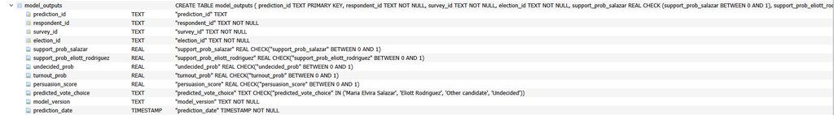

[figure not shown]

[figure not shown]

[figure not shown]

[figure not shown]